# Differential Expression Analysis (Tabbed Report)

**Significant Features**

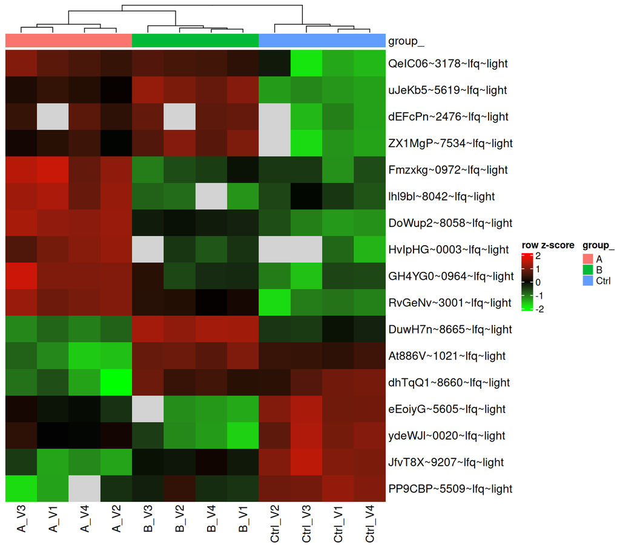

Figure 15: Heatmap of the significant differential-abundance features: rows are features called significant in at least one contrast, columns are samples, and each cell encodes the per-feature (row) z-score of the transformed abundance (row labels are shown only when at most 30 features are significant).

Table 8

| modelName | estimate_type | protein_Id | contrast | diff | avgAbd | std.error.unmoderated | df.unmoderated | std.error | statistic | df | p.value | conf.low | conf.high | sigma | FDR |
| --- | --- | --- | --- | --- | --- | --- | --- | --- | --- | --- | --- | --- | --- | --- | --- |
| lm_impute | observed | At886V~1021 | AVsC | -0.495723342361319 | 4.157260629393567 | 0.04372333941640642 | 9 | 0.04319654200189654 | -11.47599597994567 | 14.5751893411761 | 1.080734143121505e-08 | -0.5880288709420319 | -0.403417813780606 | 0.0997581406114238 | 2.701835357803762e-07 |
| lm_impute | observed | dEFcPn~2476 | AVsC | 0.5704679060990707 | 3.771364974715372 | 0.0457769716264847 | 6 | 0.06446021409807151 | 8.84992260855891 | 11.5751893411761 | 1.713638043746321e-06 | 0.4294473573109372 | 0.7114884548872042 | 0.07894731662541689 | 1.224027174104515e-05 |
| lm_impute | observed | dhTqQ1~8660 | AVsC | -0.4885359814105806 | 3.974780704649068 | 0.06641209214560093 | 9 | 0.05883897585026929 | -8.302931421746436 | 14.5751893411761 | 6.666467505061694e-07 | -0.6142674060873163 | -0.3628045567338448 | 0.1309084571049076 | 7.407186116735215e-06 |
| lm_impute | observed | DoWup2~8058 | AVsC | 0.7030932153104621 | 4.306411022670965 | 0.03231085663827111 | 9 | 0.0428112372268 | 16.42309965455338 | 14.5751893411761 | 8.329193160280309e-11 | 0.6116110341386319 | 0.7945753964822923 | 0.07509587785244114 | 8.329193160280309e-09 |
| lm_impute | observed | eEoiyG~5605 | AVsC | -0.4220876259745652 | 4.392208863160968 | 0.04749248555150329 | 8 | 0.05103807108453638 | -8.27005443202281 | 13.5751893411761 | 1.150921841131046e-06 | -0.5318756465036031 | -0.3122996054455273 | 0.08952669906930967 | 8.85324493177728e-06 |
| lm_impute | observed | Fmzxkg~0972 | AVsC | 0.6008994153095071 | 4.411450216198824 | 0.07917902125800154 | 9 | 0.07549271254544106 | 7.959700943952836 | 14.5751893411761 | 1.110927010742844e-06 | 0.4395810686883167 | 0.7622177619306975 | 0.1067628179420962 | 8.85324493177728e-06 |
| lm_impute | observed | GH4YG0~0964 | AVsC | 0.5259937315319744 | 4.200014591904983 | 0.06913593529693587 | 9 | 0.0626952824032161 | 8.389685975878022 | 14.5751893411761 | 5.872345430748805e-07 | 0.3920218691201209 | 0.6599655939438278 | 0.1211387943351661 | 7.340431788436006e-06 |
| lm_impute | observed | HvIpHG~0003 | AVsC | 0.4035848664728967 | 4.221910776182679 | 0.04365220499054252 | 6 | 0.0666351025851055 | 6.056640581552993 | 11.5751893411761 | 6.64006365394467e-05 | 0.2578062824798553 | 0.5493634504659382 | 0.07694358882997797 | 0.0002553870636132565 |
| lm_impute | observed | JfvT8X~9207 | AVsC | -0.5616676385750963 | 4.666907436797175 | 0.04946476040908915 | 9 | 0.05778208252540232 | -9.720446443379302 | 14.5751893411761 | 9.33427535536847e-08 | -0.685140616337239 | -0.4381946608129535 | 0.08171620476958537 | 1.866855071073694e-06 |
| lm_impute | observed | lhl9bl~8042 | AVsC | 0.4601907035158663 | 4.648777729338199 | 0.05056363239670056 | 8 | 0.05890037099677053 | 7.813035736924276 | 13.5751893411761 | 2.196085778541338e-06 | 0.3334900856682486 | 0.5868913213634841 | 0.08329770349243978 | 1.464057185694226e-05 |

[output cut: 13 more lines]

**Distributions**

**NoteWhy look at the fold-change and p-value distributions?**

These two histograms are model diagnostics read across all features at once, not per feature. The **fold-change** distribution should be centred near zero, because most features are not differentially abundant; a systematic shift away from zero points to a normalization or experimental-design problem rather than real biology. The **p-value** (or FDR/BFDR) distribution should be roughly uniform under the null hypothesis, with a peak near zero when true effects are present; a peak near one, or a strongly non-uniform shape, indicates that the statistical model does not describe the data well (for example unmodelled variance or outliers), so the significance calls should be interpreted with caution.

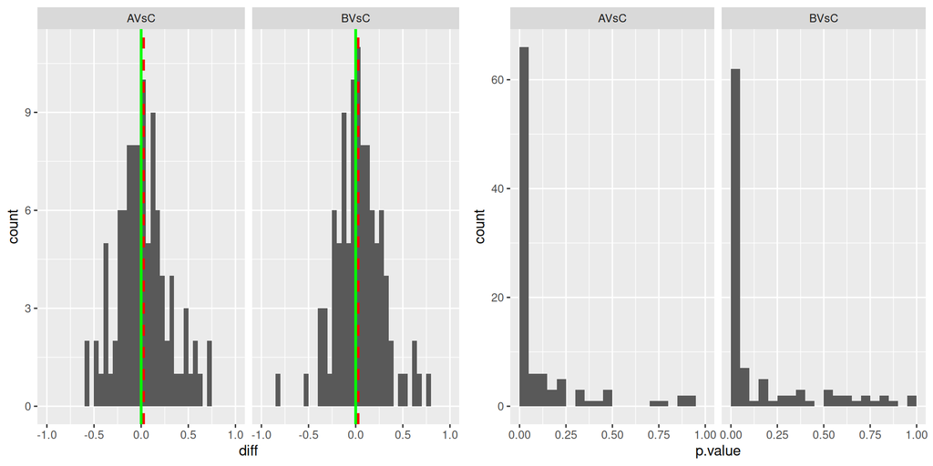

Figure 16: Distributions of the differential-abundance statistics across all features. Left: histogram of the estimated log2 fold-changes (x-axis log2 fold-change, y-axis feature count), expected to centre near zero because most features are not differentially abundant. Right: histogram of the significance score (p-value, or FDR/BFDR depending on the model; x-axis 0-1, y-axis feature count), expected to be roughly uniform with a peak near zero when true effects are present.

**Result Table**

Table 9

| modelName | estimate_type | protein_Id | contrast | diff | avgAbd | std.error.unmoderated | df.unmoderated | std.error | statistic | df | p.value | conf.low | conf.high | sigma | FDR |
| --- | --- | --- | --- | --- | --- | --- | --- | --- | --- | --- | --- | --- | --- | --- | --- |
| lm_impute | observed | At886V~1021 | AVsC | -0.495723342361319 | 4.157260629393567 | 0.04372333941640642 | 9 | 0.04319654200189654 | -11.47599597994567 | 14.5751893411761 | 1.080734143121505e-08 | -0.5880288709420319 | -0.403417813780606 | 0.0997581406114238 | 2.701835357803762e-07 |
| lm_impute | observed | dEFcPn~2476 | AVsC | 0.5704679060990707 | 3.771364974715372 | 0.0457769716264847 | 6 | 0.06446021409807151 | 8.84992260855891 | 11.5751893411761 | 1.713638043746321e-06 | 0.4294473573109372 | 0.7114884548872042 | 0.07894731662541689 | 1.224027174104515e-05 |
| lm_impute | observed | dhTqQ1~8660 | AVsC | -0.4885359814105806 | 3.974780704649068 | 0.06641209214560093 | 9 | 0.05883897585026929 | -8.302931421746436 | 14.5751893411761 | 6.666467505061694e-07 | -0.6142674060873163 | -0.3628045567338448 | 0.1309084571049076 | 7.407186116735215e-06 |
| lm_impute | observed | DoWup2~8058 | AVsC | 0.7030932153104621 | 4.306411022670965 | 0.03231085663827111 | 9 | 0.0428112372268 | 16.42309965455338 | 14.5751893411761 | 8.329193160280309e-11 | 0.6116110341386319 | 0.7945753964822923 | 0.07509587785244114 | 8.329193160280309e-09 |
| lm_impute | observed | eEoiyG~5605 | AVsC | -0.4220876259745652 | 4.392208863160968 | 0.04749248555150329 | 8 | 0.05103807108453638 | -8.27005443202281 | 13.5751893411761 | 1.150921841131046e-06 | -0.5318756465036031 | -0.3122996054455273 | 0.08952669906930967 | 8.85324493177728e-06 |
| lm_impute | observed | Fmzxkg~0972 | AVsC | 0.6008994153095071 | 4.411450216198824 | 0.07917902125800154 | 9 | 0.07549271254544106 | 7.959700943952836 | 14.5751893411761 | 1.110927010742844e-06 | 0.4395810686883167 | 0.7622177619306975 | 0.1067628179420962 | 8.85324493177728e-06 |
| lm_impute | observed | GH4YG0~0964 | AVsC | 0.5259937315319744 | 4.200014591904983 | 0.06913593529693587 | 9 | 0.0626952824032161 | 8.389685975878022 | 14.5751893411761 | 5.872345430748805e-07 | 0.3920218691201209 | 0.6599655939438278 | 0.1211387943351661 | 7.340431788436006e-06 |
| lm_impute | observed | HvIpHG~0003 | AVsC | 0.4035848664728967 | 4.221910776182679 | 0.04365220499054252 | 6 | 0.0666351025851055 | 6.056640581552993 | 11.5751893411761 | 6.64006365394467e-05 | 0.2578062824798553 | 0.5493634504659382 | 0.07694358882997797 | 0.0002553870636132565 |
| lm_impute | observed | JfvT8X~9207 | AVsC | -0.5616676385750963 | 4.666907436797175 | 0.04946476040908915 | 9 | 0.05778208252540232 | -9.720446443379302 | 14.5751893411761 | 9.33427535536847e-08 | -0.685140616337239 | -0.4381946608129535 | 0.08171620476958537 | 1.866855071073694e-06 |
| lm_impute | observed | lhl9bl~8042 | AVsC | 0.4601907035158663 | 4.648777729338199 | 0.05056363239670056 | 8 | 0.05890037099677053 | 7.813035736924276 | 13.5751893411761 | 2.196085778541338e-06 | 0.3334900856682486 | 0.5868913213634841 | 0.08329770349243978 | 1.464057185694226e-05 |

[output cut: 13 more lines]

**Session Info**

**Report provenance**

Table 10: Compact report provenance, including the source input-data reference.

| Field | Value |
| --- | --- |
| Workunit ID | 23000 |
| Order ID | 6200 |
| Project ID | 3000 |
| Project name | n/a |
| Creator | runner |
| Created at | 2026-10-23 05:11:44 UTC |
| Input data | https://fgcz-bfabric.uzh.ch/bfabric/ |
| Quantification software | DIANN |
| Model | lm_impute |
| prolfquapp version | 2.11.0 |

Table 11

| field | url |
| --- | --- |
| orderURL | https://fgcz-bfabric.uzh.ch/bfabric/order/show.html?id=6200&amp;tab=details |
| projectURL | https://fgcz-bfabric.uzh.ch/bfabric/project/show.html?id=3000&amp;tab=details |
| workunitURL | https://fgcz-bfabric.uzh.ch/bfabric/workunit/show.html?id=23000&amp;tab=details |

**R session info**

[session information not shown]

## Download

- Qmd source
- HTML page

Select all plots